# Example 8.1 Randomized complete block design

Yanming Di

2016-05-16

# Example 8.1

Read pages 264-270 of Kuehl (notes pages 60-61).

Evaluate the effect of several different fertilization timing schedules on the stem tissue nitrate amounts and wheat production to refine the recomendation procedure. There are four blocks.

## Load the data

```r
## Clean evironment is needed
rm(list=ls());

dd = read.table("../data/wheat.txt", header=TRUE);
str(dd);
```

```
## 'data.frame':    24 obs. of  3 variables:
##  $ block: int  1 1 1 1 1 1 2 2 2 2 ...
##  $ fert : int  1 2 3 4 5 6 1 2 3 4 ...
##  $ nitro: num  35 40.9 42.1 37.2 38 ...
```

```r
dd;
```

```
##    block fert nitro
## 1      1    1 34.98
## 2      1    2 40.89
## 3      1    3 42.07
## 4      1    4 37.18
## 5      1    5 37.99
## 6      1    6 34.89
## 7      2    1 41.22
## 8      2    2 46.69
## 9      2    3 49.42
## 10     2    4 45.85
## 11     2    5 41.99
## 12     2    6 50.15
## 13     3    1 36.94
## 14     3    2 46.65
## 15     3    3 52.68
## 16     3    4 40.23
## 17     3    5 37.61
## 18     3    6 44.57
## 19     4    1 39.97
## 20     4    2 41.90
## 21     4    3 42.91
## 22     4    4 39.20
## 23     4    5 40.45
## 24     4    6 43.29
```

```r
block = factor(dd$block);
fert = factor(dd$fert);
nitro = dd$nitro;
```

## Plot the data

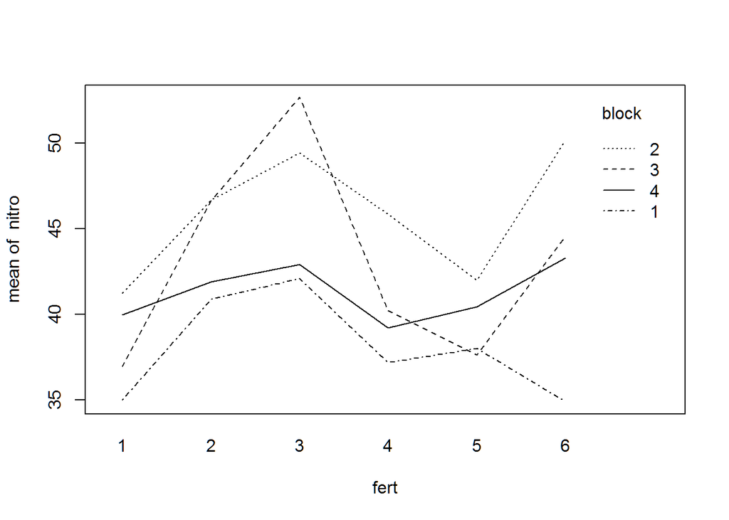

```r
interaction.plot(fert, block, nitro);
```

Note that there is no replication in each combination of block and fertilization schedule! So we cannot claim that there is no interaction between block and ferilization. In fact, we have to make some assumption about the interaction. Usually, we assume that there is no interaction.

## Fit the ANOVA model

The model is:
$$y_{ij} = \mu + \tau_i + \rho_j + e_{ij}$$

Note that we don’t have enough replicates to fit a model with interaction.

```r
m = lm(nitro ~ block + fert);
anova(m);
```

```
## Analysis of Variance Table
##
## Response: nitro
##           Df Sum Sq Mean Sq F value   Pr(>F)
## block      3 197.00  65.668  9.1198 0.001116 **
## fert       5 201.32  40.263  5.5917 0.004191 **
## Residuals 15 108.01   7.201
## ---
## Signif. codes:  0 '***' 0.001 '**' 0.01 '*' 0.05 '.' 0.1 ' ' 1
```

The test for the main effect of the treatment (fertization schedule) is the same as in the two-factor fixed effect model.

We see that fertization effect is significant (the F-test for fertilization gives a p-value is $0.004$). In other words, the mean nitrogen content varies among fertilization methods.

**The F-test for the block effect is only approximate.**

## Inference on mean contrasts

Compare the mean nitrogen content in method 3 versus method 6. The formula is the same as in a one-factor fixed effect model.

```r
## Extract MSE from the ANOVA table
a = anova(m);
ms = a$`Mean Sq`;
mse = ms[3];
df = a$Df;
dfe = df[3];

## Compute the means for each fertization schedule
mu.hat = tapply(nitro, fert, mean)
tapply(nitro, fert, length)
```

```
## 1 2 3 4 5 6
## 4 4 4 4 4 4
```

```r
## Compute the CI for the mu3 - mu6
C.hat = mu.hat[3] - mu.hat[6];

SE.Chat = sqrt(mse * (1/4+1/4));

alpha = 0.05;
t.cr = qt(1-alpha/2, df=dfe);

CI = C.hat + c(-1,1) * t.cr * SE.Chat;

CI
```

```
## [1] -0.4992988  7.5892988
```

With $95\%$ confidence, the difference in the mean nitrogen content from the two fertilization methods 3 and 6 is between $(-0.4992988, 7.5892988)$.

The above calculation is also correct when block is considered a random effect factor. However, in that case the variance of the mean levels will be greater than the MSE from the ANOVA table.

## Model diagnostics

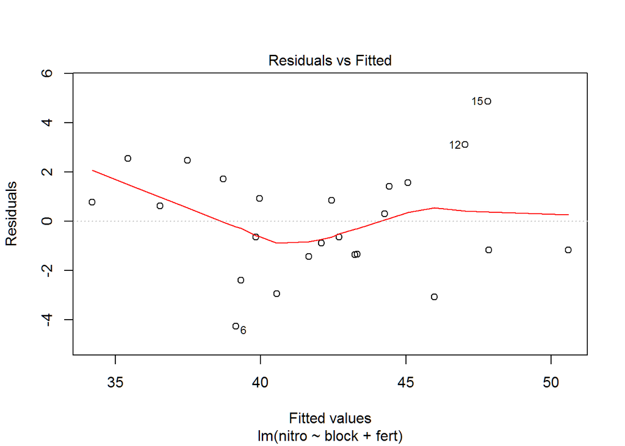

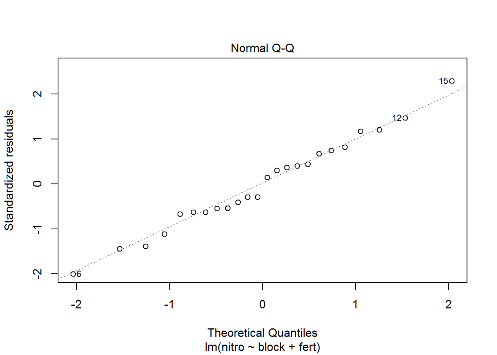

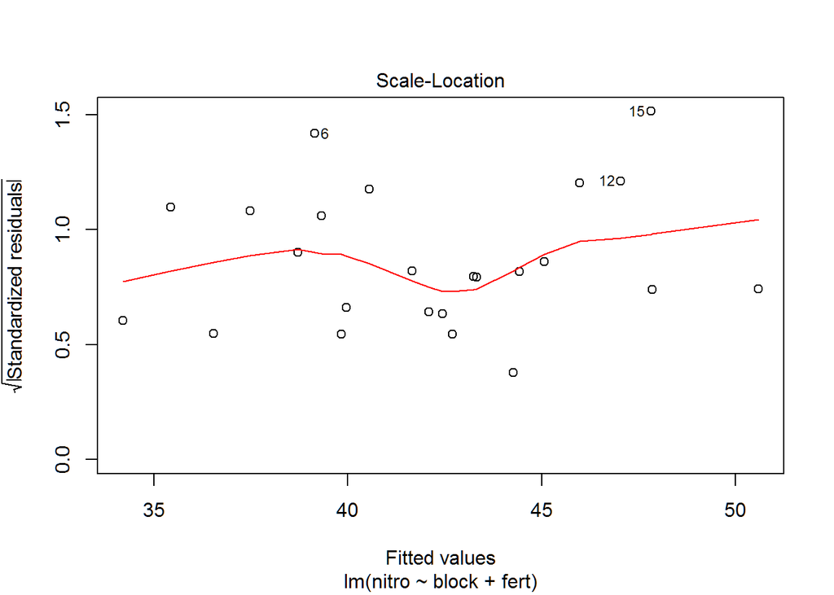

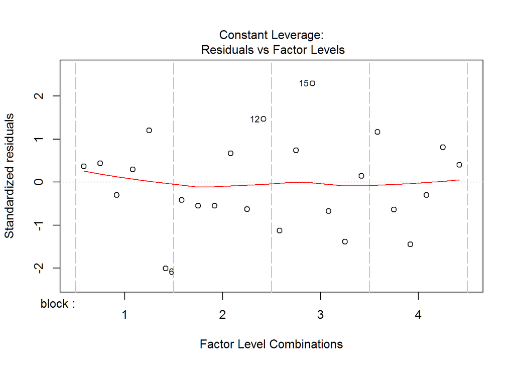

```r
plot(m)
```

## Relative efficiency of RCB

Read notes pages 63-64.

```r
## ANOVA table
a = anova(m);
a
```

```
## Analysis of Variance Table
##
## Response: nitro
##           Df Sum Sq Mean Sq F value   Pr(>F)
## block      3 197.00  65.668  9.1198 0.001116 **
## fert       5 201.32  40.263  5.5917 0.004191 **
## Residuals 15 108.01   7.201
## ---
## Signif. codes:  0 '***' 0.001 '**' 0.01 '*' 0.05 '.' 0.1 ' ' 1
```

```r
## EXtract SS and MS from ANOVA table
ms = a$`Mean Sq`;
ss = a$`Sum Sq`;

## Number of treatment
t = 6;

## Number of blocks
r = 4;
```

Estimate $\sigma_{rcb}^2$ by $s_{rcb}^2 = MSE = 7.2005611$.

Estimate $\sigma_{cr}^2$ by
$$s_{cr}^2=\frac{SS Block + r(t-1) MSE}{rt -1} = \frac{197.0039333 + 4 (6-1) 7.2005611}{4 \times 6 -1} = 14.8267459$$

The relative efficiency is
$$RE = \dfrac{s_{cr}^2}{s_{rcb}^2} = \dfrac{14.8267459}{7.2005611} = 2.0591098.$$

## Friedman’s test

```r
friedman.test(nitro, groups = fert, blocks = block)
```

```
##
##  Friedman rank sum test
##
## data:  nitro, fert and block
## Friedman chi-squared = 12.714, df = 5, p-value = 0.02621
```

```r
## Do the test "by hand"

## 1. Within each block, rank the responses.
R = tapply(nitro, block, rank);
R;
```

```
## $`1`
## [1] 2 5 6 3 4 1
##
## $`2`
## [1] 1 4 5 3 2 6
##
## $`3`
## [1] 1 5 6 3 2 4
##
## $`4`
## [1] 2 4 5 1 3 6
```

```r
## Convert the list to a matrix
t = 6;
r = 4;
R = matrix(unlist(R), r, t, byrow=TRUE);
R
```

```
##      [,1] [,2] [,3] [,4] [,5] [,6]
## [1,]    2    5    6    3    4    1
## [2,]    1    4    5    3    2    6
## [3,]    1    5    6    3    2    4
## [4,]    2    4    5    1    3    6
```

```r
## 2. Compute Ri., R..
R.. = (t+1)/2;
Ri. = colMeans(R);
Ri.
```

```
## [1] 1.50 4.50 5.50 2.50 2.75 4.25
```

```r
R..
```

```
## [1] 3.5
```

```r
## 3. Compute S
S = 12 * r / (t * (t+1)) * sum((Ri. - R..)^2);

## 4. Compute p-value: compare S to a chi-square distribution with (t-1) df.
p = 1 - pchisq(S, df=t-1);

list(S=S, p=p)
```

```
## $S
## [1] 12.71429
##
## $p
## [1] 0.02620852
```

## *The wrong way*

If we ignore blocks, **which is wrong**, the fertilizatioon effect will no longer be significant.

```r
## Wrong way to analyze RCB data!
m1 = lm(nitro ~ fert);
anova(m1);
```

```
## Analysis of Variance Table
##
## Response: nitro
##           Df Sum Sq Mean Sq F value  Pr(>F)
## fert       5 201.32  40.263  2.3761 0.08024 .
## Residuals 18 305.01  16.945
## ---
## Signif. codes:  0 '***' 0.001 '**' 0.01 '*' 0.05 '.' 0.1 ' ' 1
```

If we use the MSE from this wrong model, the CI for the contrast of means will be wider than the correct one.